# Beyond R Packages - An History of Collaborations

Thomas Vroylandt

For all R users, CRAN is the place were you can find most of the packages you need to run code. Last month, I saw this Xkcd drawing :

[figure not shown]

And this remind me of something : behind packages, you can find people. And this people are at the heart of all your analytics pipelines because they build, maintain and develop R packages. It’s their ideas and their work, discussion and collaborations that made R as it is. One example of it is the [fantastic story of the pipe](http://adolfoalvarez.cl/plumbers-chains-and-famous-painters-the-history-of-the-pipe-operator-in-r/) (`%>%`) by Adolfo Alvarez.

Let’s talk a bit about this people and their packages !

## Which packages are we talking about ?

Not all packages on CRAN are equal. They are all useful and all needed a big bunch of work. But some are more useful than others, also because they are more general.

I try to appreciate it by comparing two things :

- how much the package has been downloaded ?
- how many packages use the package as a dependency ?

For the first one, I used `{cranlogs}`, a package which show the download statistics for the RStudio CRAN mirror, from 2013 to now. It’s not all the CRAN downloads but it’s a nice part of them. We choose to compute the median download by month for each package, since it’s first appearance (so for months with more than 0 download). I did so since we got some strange stats for packages like `{tidyverse}` with an incredible amount of downloads in november 2018 or a big amount of downloads for `{aws.s3}` over the last year that I couldn’t understand.

For the dependency count, I used some centrality measures from graph network theory. What is important to me is to know how much times the package is listed as a dependency (so in-degree centrality), how many dependency it has (out-degree centrality) and if the package is “important” in the global network of the dependency graph. For this last measure, I used PageRank centrality, the same algorithm as Google.

With all of that, we get the following table with all the packages on CRAN :

| package | title | median_download | min_year | nb_authors | nb_deps | nb_is_deps | list_views |
| --- | --- | --- | --- | --- | --- | --- | --- |
| A3 | Accurate, Adaptable, and Accessible Error Metrics for Predictive Models | 503 | 2013 | 1 | 2 | 0 | NA |
| aaSEA | Amino Acid Substitution Effect Analyser | 640.5 | 2019 | 1 | 9 | 0 | NA |
| AATtools | Reliability and Scoring Routines for the Approach-Avoidance Task | 473 | 2020 | 1 | 4 | 0 | NA |
| ABACUS | Apps Based Activities for Communicating and Understanding Statistics | 601 | 2019 | 1 | 3 | 0 | NA |
| abbyyR | Access to Abbyy Optical Character Recognition (OCR) API | 523 | 2015 | 1 | 6 | 0 | WebTechnologies |
| abc | Tools for Approximate Bayesian Computation (ABC) | 796 | 2013 | 4 | 5 | 4 | Bayesian |
| abc.data | Data Only: Tools for Approximate Bayesian Computation (ABC) | 885 | 2015 | 4 | 0 | 1 | NA |
| ABC.RAP | Array Based CpG Region Analysis Pipeline | 388.5 | 2016 | 3 | 3 | 0 | NA |
| abcADM | Fit Accumulated Damage Models and Estimate Reliability using ABC | 578 | 2019 | 3 | 3 | 0 | NA |
| ABCanalysis | Computed ABC Analysis | 493.5 | 2015 | 1 | 1 | 0 | NA |

[output cut: 16143 more lines]

I gathered the main infos in a graph, crossing centrality (in-degree) and popularity (downloads). I annotate some main areas :

- on the right of the graph, a lot of packages, very popular like `{dplyr}` or `{ggplot2}` (the whole `{tidyverse}` collection in fact) or `{httr}`. This packages are direct downloads from the people. They are widely-used. A lot of packages depends of them.
- on the top-left, some more unknown packages to neophytes like `{ellipsis}`, `{vctrs}`, `{pillar}`, etc. This packages have a lot of downloads but are only listed as a dependency by a few but very important packages. In fact they are more “infrastructure” packages. They are the foundations of some more-used packages and they hide the more low-level functions. So we can guess that the downloads are not direct downloads but come from the download of other packages.
- some other packages, in the middle between the two above categories, like `{rlang}` or `{Rcpp}` could be the most important R packages. We should also notice that they have a 0 out-degree centrality, so they depends on zero other package (they are root packages).

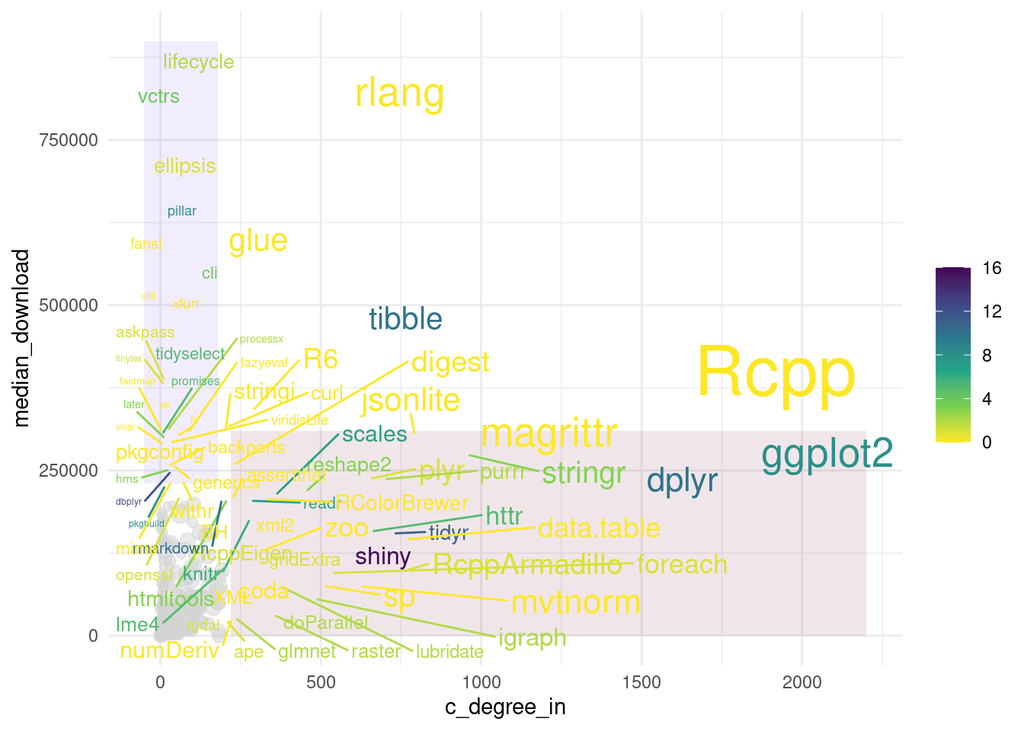

## And the authors ?

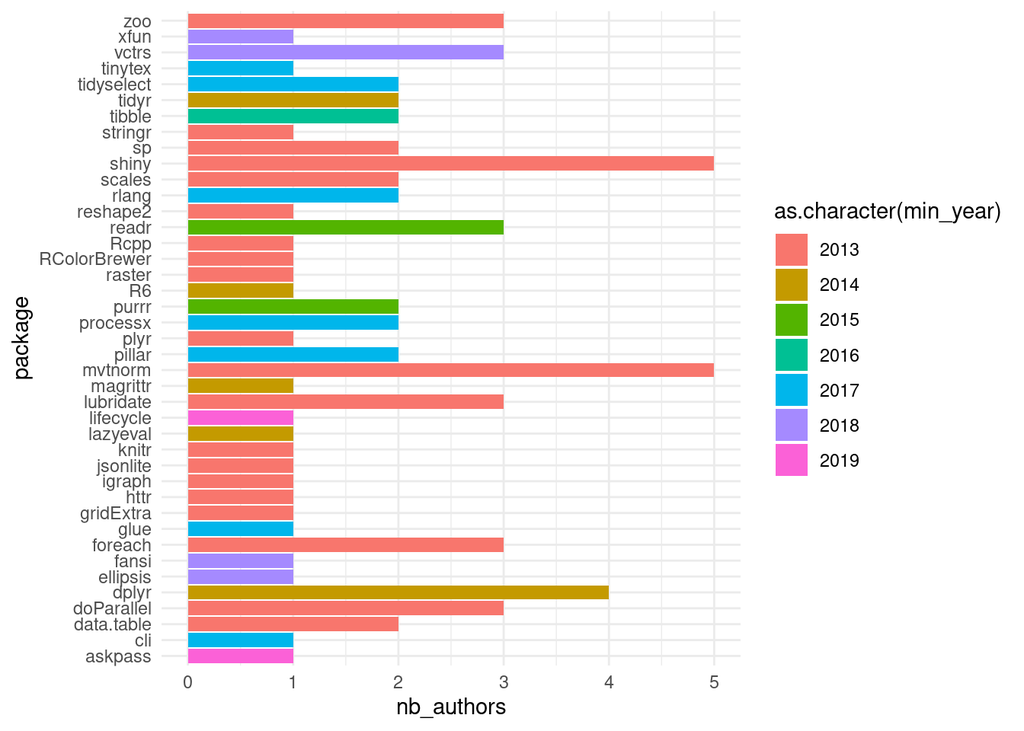

## Authors collaborations

Number of collaborator / authors on main packages ?

- who are maintaining both of them ? People ? Organizations ? Collaborations ?
- by thematic / views ?
- who collaborate with whom ?
- path from package to people behind them ! = community

Authors network -> dependencies : who develop package on which other packages are built on ?